# Topic Classification

### Class 2 analysis

[output not shown]

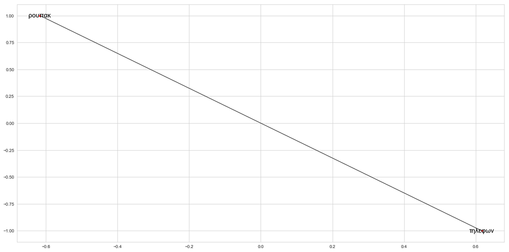

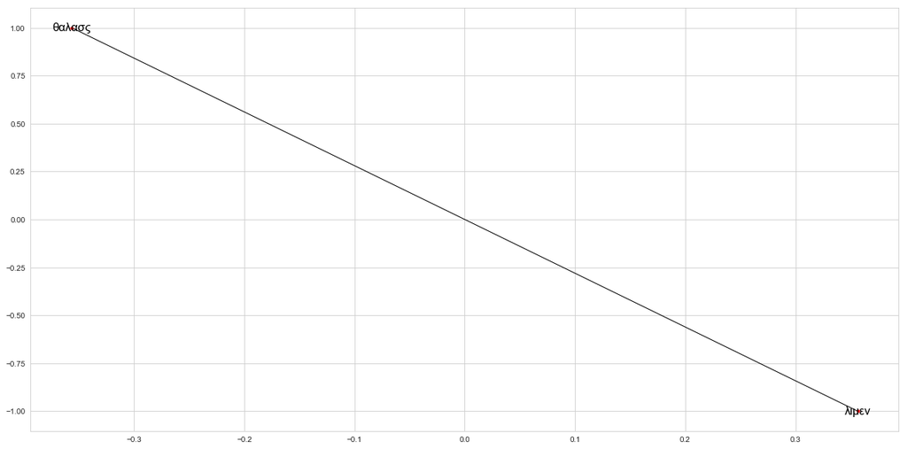

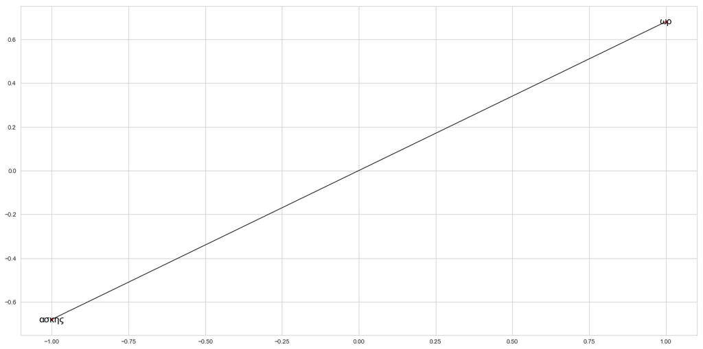

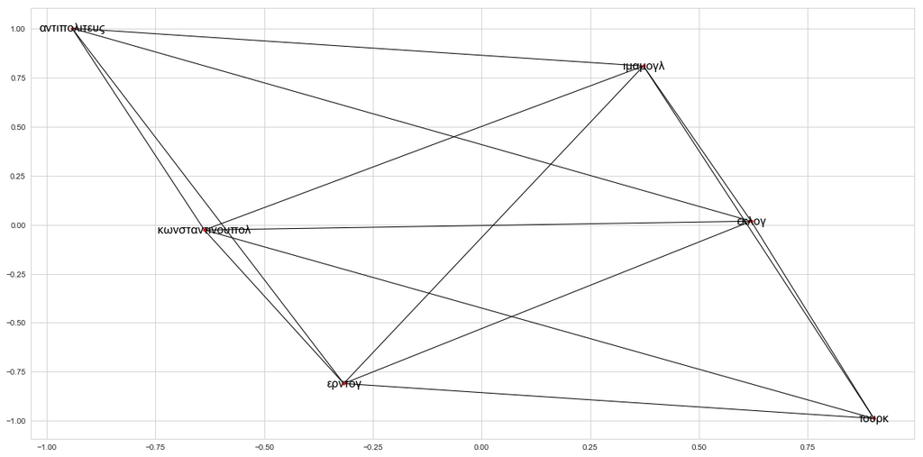

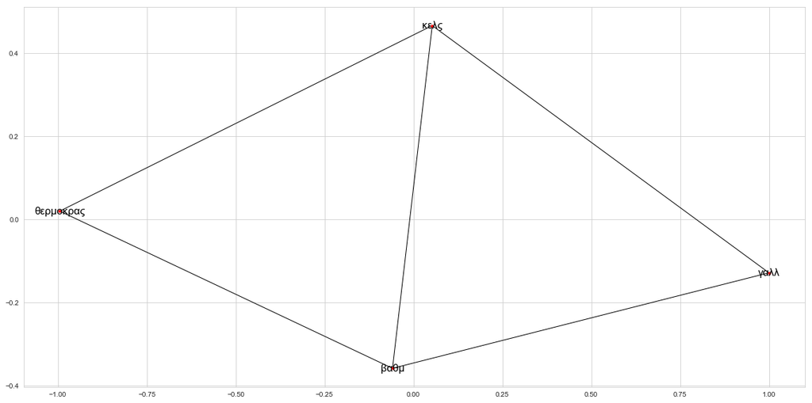

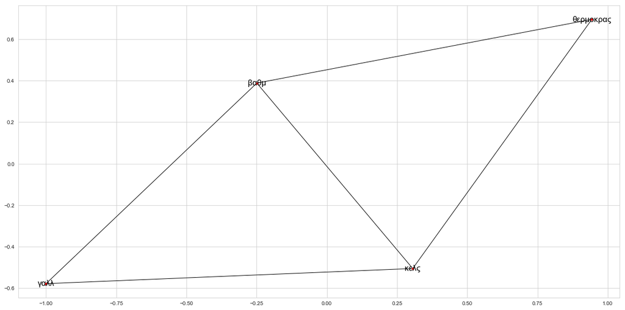

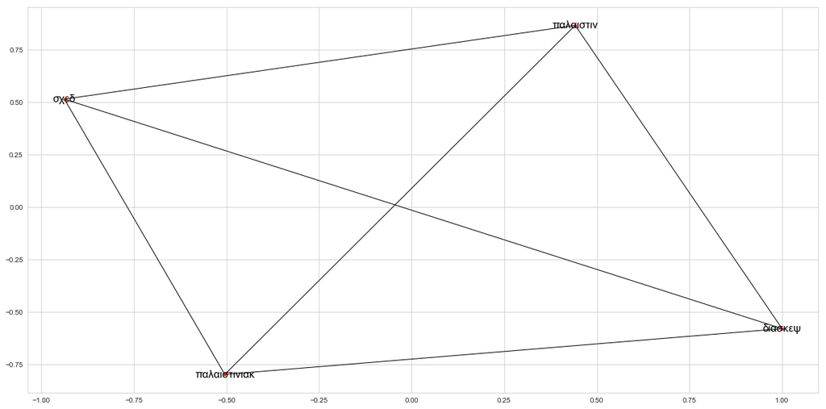

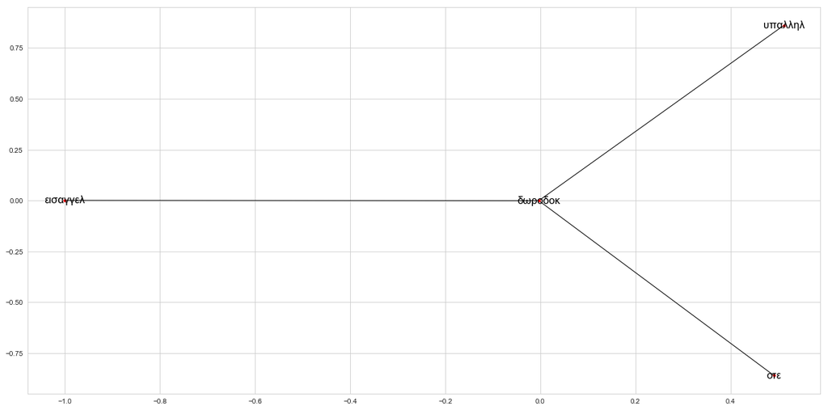

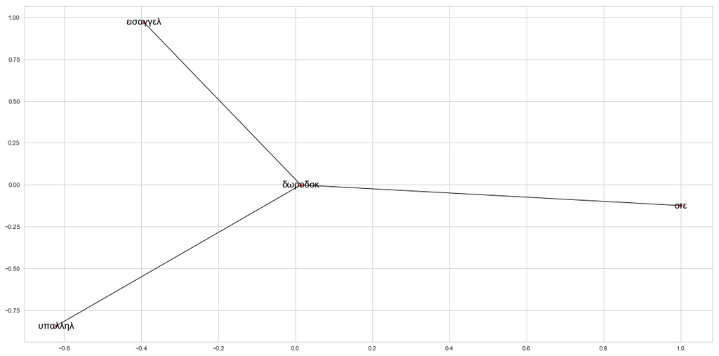

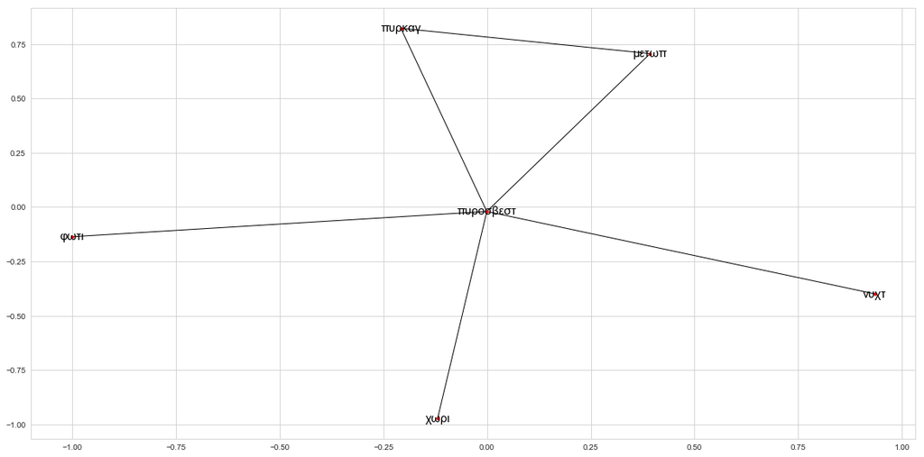

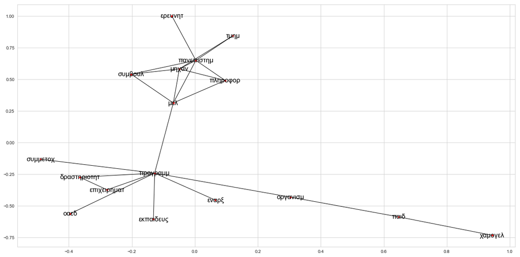

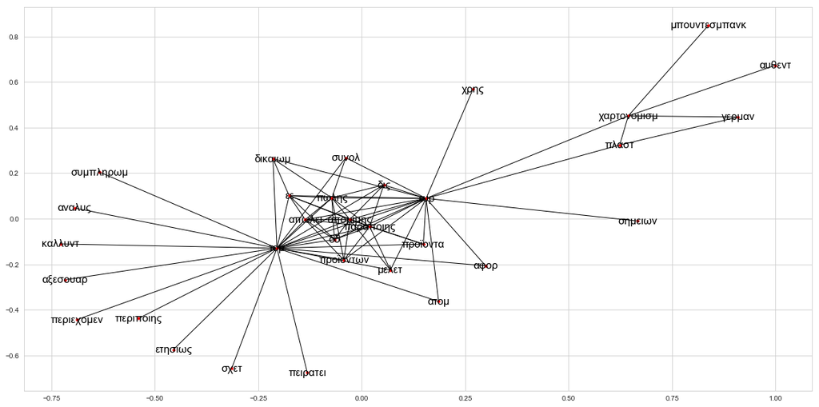

[6 more figures not shown]

```python
graph_file= 'word_network_class_1.weighted.edgelist'
res= 0.8
support_threshold= 85

#pre-process the grapgh
G, big_cb= preprocessing(graph_file, 4, support_threshold) #second parameter: minimum size of connected components to keep

#find communities
communities2, communitiesInfo= community_detection(G,big_cb,res)

for chosenCom, _,_ in communitiesInfo:
    comG= G.subgraph(communities2[chosenCom])
    drawGraph(comG)
```

# As the classification task follows, let's proceed in Feature Extraction due to the small number of articles (500).

```python
word_to_com1_map= {token:com_id for com_id,token_list in communities1.items() for token in token_list}
com_size_dict1= {com_id:len(token_list) for com_id,token_list in communities1.items()}
max_size1= max(com_size_dict1.values())

word_to_com2_map= {token:com_id for com_id,token_list in communities2.items() for token in token_list}
com_size_dict2= {com_id:len(token_list) for com_id,token_list in communities2.items()}
max_size2= max(com_size_dict2.values())
```

```python
def get_additional_features(communities,word_to_com_map,com_size_dict,max_size):
    feats1= np.zeros((corpus.shape[0],len(communities.keys())))
    feats2= np.zeros((corpus.shape[0],len(communities.keys())))
    for i,doc in enumerate(corpus):

        #get all the tokens
        words= my_tokenizer(my_preprocessor(doc))

        #per community count
        com_occ= [word_to_com_map[word] for word in words if word in word_to_com_map]

        coms, cnts= np.unique(com_occ, return_counts=True)

        #feats - case 1: #words per community
        for c_i in range(len(coms)):
            feats1[i,coms[c_i]]= cnts[c_i]
            feats2[i,coms[c_i]]= cnts[c_i]/com_size_dict[coms[c_i]]

        return np.concatenate((feats1,feats2),axis=1)
```

```python
additional_feats1= get_additional_features(communities1,word_to_com1_map,com_size_dict1,max_size1)
additional_feats2= get_additional_features(communities2,word_to_com2_map,com_size_dict2,max_size2)

additional_feats= np.concatenate((additional_feats1,additional_feats2),axis=1)

#z-standatization result in large values, so we use max standarization
sc = MinMaxScaler()
additional_feats_sc= sc.fit_transform(additional_feats)
```

# Classification

## Classification with Bag of Words | Tf-idf

### Pre-preprocessing

#### Train/Test Split

Instead of sklearn train_test_split method, we implement our own one in order to have the **exact** same split in both the cases of the below classifiers (sklearn) and the LSTM (pytorch)</h4>

```python
#force the random split to be the same over the model optimization process
def my_train_validation_split(X, y, ratio=[0.8,0.2], random_state=None):
    #np.random.seed(random_state)
    #indices of articles within each class
    y0_idx= np.hstack(np.argwhere(y==0))
    y1_idx= np.hstack(np.argwhere(y==1))

    #indices in-place shuffling
    np.random.shuffle(y0_idx)
    np.random.shuffle(y1_idx)

    #split
    dataset_size= X.shape[0]
    train_size= int(ratio[0]*dataset_size//2)

    train_idx= np.concatenate((y0_idx[:train_size], y1_idx[:train_size]))
    test_idx= np.concatenate((y0_idx[train_size:], y1_idx[train_size:]))

    return train_idx, test_idx
```

We split our data to train/ test sets for convenience purposes. The selected test set will never be used for model tuning and selection. It will be hidden from our models till the end of our demonstration in order to simulate real-life problems or competitions. For that reason, the initial traing set will be split to train and validation set for model selection purposes.

```python
train_idx, test_idx = my_train_validation_split(corpus, y, random_state=42)
```

#### Tf-idf scheme

For classification purposes we used the stemmed version of the Tf-idf representation. During our research, it was found that it tended to raise a bit the performance of our models.

```python
#create tf-idf
vectorizer_stem = TfidfVectorizer(preprocessor=my_preprocessor, tokenizer=my_tokenizer, min_df=5) #keep words that are being used in at least 5 documents (1%)
corpus_tf_idf_train = vectorizer_stem.fit_transform(corpus[train_idx]).toarray()
print('So, we resulted in {} unique tokens'.format(corpus_tf_idf_train.shape[1]))

corpus_tf_idf_test= vectorizer_stem.transform(corpus[test_idx]).toarray()
```

```
So, we resulted in 1525 unique tokens
```

#### Merge Tf-idf Representation with Community Detection Features

```python
corpus_tf_idf_add_train= np.concatenate((corpus_tf_idf_train,additional_feats_sc[train_idx,:]), axis=1)
corpus_tf_idf_add_test= np.concatenate((corpus_tf_idf_test,additional_feats_sc[test_idx,:]), axis=1)
```

#### Dimensionality Reduction (PCA)

We will use a reduced version of the dataset for classification purposes given that dimensions are more than samples!

```python
pc_num= 300
pca = PCA(n_components=pc_num)
corpus_reduced_train= pca.fit_transform(corpus_tf_idf_train)
print('Starting from {} initial features, we kept only {} ({:.2f}%), which explain the {:.2f}% of the variance of our data'.
      format(corpus_tf_idf_train.shape[1], pc_num, pc_num*100/corpus_tf_idf_train.shape[1], sum(pca.explained_variance_ratio_)*100))

corpus_reduced_test= pca.transform(corpus_tf_idf_test)
```

```
Starting from 1525 initial features, we kept only 300 (19.67%), which explain the 92.86% of the variance of our data
```

```python
X_train, y_train= corpus_reduced_train, y[train_idx]
X_test, y_test= corpus_reduced_test, y[test_idx]
```

**Linear Discriminant Analysis** was also considered but it is not appropriate for our case, given that i can return us up to only 2 features (since #classes=2).

## Model selection

### Initial Classifiers

A k-fold cross validation scheme will be used for model selection purposes.

```python
cv = KFold(5)
```

In this section we use a variety of classifiers common in NLP problems and test their performance with default parameters and evaluate them by using cross validation.

```python
clfs= [[LogisticRegression(solver='lbfgs'),'Logistic Regression'],
      [SVC(kernel='linear',gamma='scale'),'SVM linear'],
      [SVC(kernel='poly',gamma='scale'),'SVM poly'],
      [SVC(kernel='rbf',gamma='scale'),'SVM rbf'],
      [KNeighborsClassifier(n_neighbors=3),'k-NN'],
      [GaussianNB(),'Gaussian Naive Bayes'],
      [XGBClassifier(), 'XGBoost'],
      [LGBMClassifier(), 'LightGBM'],
      [AdaBoostClassifier(base_estimator=SVC(C = 1, kernel='linear', gamma='scale', probability=True),
                          n_estimators=50, learning_rate=0.5, algorithm='SAMME.R', random_state=None), 'AdaBoostSVM']]

cv_scores = {}
for clf, name in clfs:
    cv_score = np.mean(cross_val_score(clf, X_train, y_train, cv=cv))
    cv_scores[name] = cv_score
print("Cross validation scores on visible set (X_train)")
cv_scores = {k: v for k, v in sorted(cv_scores.items(), key=lambda item: item[1], reverse=True)}
for key, value in cv_scores.items():
    print("{:.3f} [{}]".format(value, key))
```

```
Cross validation scores on visible set (X_train)
0.910 [AdaBoostSVM]
0.900 [LightGBM]
0.890 [XGBoost]
0.860 [Gaussian Naive Bayes]
0.857 [SVM linear]
0.840 [k-NN]
0.820 [SVM rbf]
0.750 [Logistic Regression]
0.260 [SVM poly]
```

Accuracy is being used because:

- each class is equally important
- the dataset is balanced

Our results are already satisfying. Let's tune...

### Hyperparameter tuning with GridSearch and Cross Validation

In this section we implement some code for tuning the model parameters. We leave out the Gradient boosting algorithms in order to reduce complexity and given that they already follow an iterative optimisation process. (Random forest algorithm was also considered but was too slow and bad performing)

```python
# =============================================================================
# Classifier tuning with cross-validation based gridsearch
# =============================================================================

## Define Classifiers with their names
algorithms = {'SVM rbf': SVC(),'SVM poly': SVC(),'SVM linear': SVC(),
              'k-NN': KNeighborsClassifier()}

# Define hyperparameter grid respectively
param_grid = [{'kernel': ['rbf'], 'gamma': ['scale', 'auto'], 'C': [0.1, 1, 10]},
                    {'kernel': ['poly'], 'gamma': ['scale', 'auto'],'C': [1, 10, 100], 'degree':(2,3,4)},
                    {'kernel': ['linear'], 'gamma': ['scale', 'auto'], 'C': [0.1, 1, 10]},
                    {'n_neighbors': list(range(3, 25, 2)), 'weights': ['uniform', 'distance']},
                    {},{}]

cv_scores, _ = grid_tuning(X_train=X_train, y_train=y_train, algorithms=algorithms,
                            param_grid=param_grid, folds=10)
```

```
Tuning hyper-parameters, based on accuracy for: SVM rbf
with parameter choice:
{'kernel': ['rbf'], 'gamma': ['scale', 'auto'], 'C': [0.1, 1, 10]}
Best parameter set found on training set:
{'C': 10, 'gamma': 'scale', 'kernel': 'rbf'}
CV results of best model: 0.935
===============================

Tuning hyper-parameters, based on accuracy for: SVM poly
with parameter choice:
{'kernel': ['poly'], 'gamma': ['scale', 'auto'], 'C': [1, 10, 100], 'degree': (2, 3, 4)}
Best parameter set found on training set:
{'C': 1, 'degree': 2, 'gamma': 'scale', 'kernel': 'poly'}
CV results of best model: 0.915
===============================

Tuning hyper-parameters, based on accuracy for: SVM linear
with parameter choice:
{'kernel': ['linear'], 'gamma': ['scale', 'auto'], 'C': [0.1, 1, 10]}
Best parameter set found on training set:
{'C': 1, 'gamma': 'scale', 'kernel': 'linear'}
CV results of best model: 0.917
===============================

Tuning hyper-parameters, based on accuracy for: k-NN
with parameter choice:
{'n_neighbors': [3, 5, 7, 9, 11, 13, 15, 17, 19, 21, 23], 'weights': ['uniform', 'distance']}
Best parameter set found on training set:
{'n_neighbors': 19, 'weights': 'uniform'}
CV results of best model: 0.907
===============================

Finished!
```

Here we define the final parameters of the tuned classifiers as derived from gridsearch and store them into a dictionary:

```python
models = {'SVM rbf': SVC(C = 10, kernel='rbf', gamma='scale', probability=True),
          'SVM poly': SVC(C = 1, kernel='poly', degree=2, gamma='scale', probability=True),
          'SVM linear': SVC(C = 1, kernel='linear', gamma='scale', probability=True),
          'k-NN': KNeighborsClassifier(n_neighbors=19,weights='uniform'),
          'Gaussian Naive Bayes': GaussianNB(),
          'Logistic Regression': LogisticRegression(solver='lbfgs')}
```

We recalculate cross validation scores of the tuned classifiers for completeness purposes:

```python
cv = KFold(5)
scores = {}
for (name, clf) in models.items():
    cv_score = np.mean(cross_val_score(clf, X_train, y_train, cv=cv))
    scores[name] = cv_score
print("Tuned classifiers cross validation scores on visible set (X_train)")
scores = {k: v for k, v in sorted(scores.items(), key=lambda item: item[1], reverse=True)}
for key, value in scores.items():
    print("{:.3f} [{}]".format(value, key))
```

```
Tuned classifiers cross validation scores on visible set (X_train)
0.860 [Gaussian Naive Bayes]
0.857 [SVM linear]
0.845 [SVM rbf]
0.795 [k-NN]
0.750 [Logistic Regression]
0.652 [SVM poly]
```

### Bagging

In this section we seek to improve the performance of the tuned simple classifiers by applying the well known bootstrap aggregating method by using different number of bags in each iteration. We compare results to the previous ones of the tuned classifiers.

```python
# =============================================================================
# 18b. Bagging Classifiers
# =============================================================================
print("Bagging Results (CV):\n")
for n in [10, 15,20]:
    print("Number of bags: {}".format(n))
    for model in models:
        bcl = BaggingClassifier(base_estimator = models[model] , n_jobs= -1, n_estimators = n)
        cv_score = np.mean(cross_val_score(bcl, X_train, y_train, cv=cv))
        print("{:.3f} [{}] -> Improvement: {:.3f} ".
              format(cv_score, model, cv_score - scores[model]))
    print("============================================")
```

```
Bagging Results (CV):

Number of bags: 10
0.897 [SVM rbf] -> Improvement: 0.052
0.885 [SVM poly] -> Improvement: 0.233
0.872 [SVM linear] -> Improvement: 0.015
0.775 [k-NN] -> Improvement: -0.020
0.850 [Gaussian Naive Bayes] -> Improvement: -0.010
0.740 [Logistic Regression] -> Improvement: -0.010
============================================
Number of bags: 15
0.903 [SVM rbf] -> Improvement: 0.058
0.870 [SVM poly] -> Improvement: 0.218
0.880 [SVM linear] -> Improvement: 0.022
0.802 [k-NN] -> Improvement: 0.007
0.840 [Gaussian Naive Bayes] -> Improvement: -0.020
0.702 [Logistic Regression] -> Improvement: -0.048
============================================
Number of bags: 20
0.897 [SVM rbf] -> Improvement: 0.052
0.887 [SVM poly] -> Improvement: 0.235
0.878 [SVM linear] -> Improvement: 0.020
0.795 [k-NN] -> Improvement: 0.000
0.853 [Gaussian Naive Bayes] -> Improvement: -0.007
0.723 [Logistic Regression] -> Improvement: -0.027
============================================
```

```python
models['Bagging SVM rbf'] = BaggingClassifier(base_estimator=SVC(C = 1, kernel='rbf', gamma='scale',
                                                     probability=True), n_jobs=-1, n_estimators = 15)
models['Bagging SVM poly'] = BaggingClassifier(base_estimator=SVC(C = 1, kernel='poly', gamma='scale',
                                                     probability=True), n_jobs=-1, n_estimators = 20)
models['AdaBoostSVM'] = clfs[-1][0]
models['XGBoost'] = XGBClassifier()
models['LightGBM'] = LGBMClassifier()
```

### Evaluation of chosen models using the "recall" metric.

In this section we evaluate our classifiers using recall in order to discover their biases in terms of classes and decide if we need to proceed to voting methods.

```python
X_train_tmp, X_validation_tmp, y_train_tmp, y_validation_tmp = train_test_split(X_train, y_train, test_size=0.33)

scores = evaluate_classifiers(X_train=X_train_tmp, y_train=y_train_tmp, X_test=X_validation_tmp, y_test=y_validation_tmp,
                                     models=models, metric='Recall')
```

```
SVM rbf
Recall: [0.84848485 0.93939394]
SVM poly
Recall: [0.77272727 0.98484848]
SVM linear
Recall: [0.86363636 0.89393939]
k-NN
Recall: [0.98484848 0.77272727]
Gaussian Naive Bayes
Recall: [0.77272727 0.93939394]
Logistic Regression
Recall: [0.89393939 0.93939394]
Bagging SVM rbf
Recall: [0.86363636 0.93939394]
Bagging SVM poly
Recall: [0.68181818 1.        ]
AdaBoostSVM
Recall: [0.81818182 0.96969697]
XGBoost
Recall: [0.95454545 0.87878788]
LightGBM
Recall: [0.93939394 0.92424242]
```

Based on the imbalanced recall values we can still try to combine them in order to improve performance.

### Voting

The final step is to collect 3 of the best and most "dissonant" classifiers from above in terms of recall and combine them using a voting process so as to optimise our predictions. This means that we choose to combine 2 classifiers that tend to better predict class 0 with those that better predict class 1. The third classifier added to the scheme is chosen to be an "unbiased" (balanced) classifier in order to smoothen the conflicts between the two abovementioned classifiers.  
So, we chose to keep LightGBM and combine AdaBoostSVM and k-NN which are quick and simple as the dissonant classifiers (kNN consistenly favoured class 0 in terms of recall). It may seem surprising but this simple set of models proved to be the most robust one during our different experiments and that's why we go on with this voting combination. Bagging classifiers were avoided for time efficiency purposes.

```python
#knn best predicts 0, others best predict 1
# implemented for 3 algorithms
# choose algorithms here by their names as in the dict above
alg1= 'LightGBM'
alg2= 'k-NN'
alg3= 'AdaBoostSVM'
_, y_pred_hard = voting3(X_train=X_train_tmp, y_train=y_train_tmp, X_test=X_validation_tmp, y_test=y_validation_tmp, models=models,
                         alg1=alg1, alg2=alg2, alg3=alg3, voting='hard', scores=scores, n_folds=None)
_, y_pred_soft = voting3(X_train=X_train_tmp, y_train=y_train_tmp, X_test=X_validation_tmp, y_test=y_validation_tmp, models=models,
                         alg1=alg1, alg2=alg2, alg3=alg3, voting='soft', scores=scores, n_folds=None)
```

```
hard voting:
              precision    recall  f1-score   support

           0      0.878     0.985     0.929        66
           1      0.983     0.864     0.919        66

    accuracy                          0.924       132
   macro avg      0.931     0.924     0.924       132
weighted avg      0.931     0.924     0.924       132

Accuracy scores (Test set):
LightGBM: 0.932, k-NN: 0.879, AdaBoostSVM: 0.894, hard ensemble: 0.924
Finished voting!
=====================================================
soft voting:
              precision    recall  f1-score   support

           0      0.914     0.970     0.941        66
           1      0.968     0.909     0.937        66

    accuracy                          0.939       132
   macro avg      0.941     0.939     0.939       132
weighted avg      0.941     0.939     0.939       132

Accuracy scores (Test set):
LightGBM: 0.932, k-NN: 0.879, AdaBoostSVM: 0.894, soft ensemble: 0.939
Finished voting!
=====================================================
```

### Test set performance

```python
final = VotingClassifier(estimators=[(alg1, models[alg1]), (alg2, models[alg2]),
                                   (alg3, models[alg3])], voting="soft")
final.fit(X_train, y_train)
y_pred = final.predict(X_test)
print(classification_report(y_test,y_pred))
```

```
              precision    recall  f1-score   support

           0       0.87      0.95      0.91        43
           1       0.96      0.89      0.93        57

    accuracy                           0.92       100
   macro avg       0.92      0.92      0.92       100
weighted avg       0.92      0.92      0.92       100
```

### Test set confusion matrix

In this section we also plot the confusion matrix of the chosen ensemble model for further evaluation.

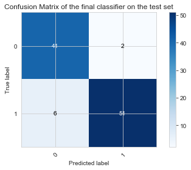

```python
fig, ax = plt.subplots()
plot_confusion_matrix(y_test, y_pred, fig, ax, allClasses=np.arange(2), title='Confusion Matrix of the final classifier on the test set')
plt.savefig(images_path+"final_CM.png")
```

## Classification with Word Embedding | LSTM

#### create & save word embeddings

```python
#download word embeddings
bert_embedding = BertEmbedding(model='bert_12_768_12', dataset_name='wiki_multilingual_uncased')
```

```
Vocab file is not found. Downloading.
Downloading C:\Users\Karolos\.mxnet\models\wiki_multilingual_uncased-2b2514cc.zip from https://apache-mxnet.s3-accelerate.dualstack.amazonaws.com/gluon/dataset/vocab/wiki_multilingual_uncased-2b2514cc.zip...
Downloading C:\Users\Karolos\.mxnet\models\bert_12_768_12_wiki_multilingual_uncased-237f3985.zip from https://apache-mxnet.s3-accelerate.dualstack.amazonaws.com/gluon/models/bert_12_768_12_wiki_multilingual_uncased-237f3985.zip...
```

```python
#get the vocabulary
vocabulary= vectorizer_no_stem.get_feature_names()

#exract the word embeddings
word_embeddings= {}
for word in vocabulary:
    word_embeddings[word]= bert_embedding([word])[0][1][0]

#save the word embeddings
with open(pickles_path+'word_embeddings.pickle', 'wb') as handle:
    pickle.dump(word_embeddings, handle, protocol=pickle.HIGHEST_PROTOCOL)
```

#### load word embeddings and create the new corpus

```python
#load the word embeddings
with open(pickles_path+'word_embeddings.pickle', 'rb') as handle:
    word_embeddings = pickle.load(handle)

#create the corpus
corpus_we= []
for i,doc in enumerate(corpus):
    doc_we= []
    for word in no_stem_tokenizer(my_preprocessor(doc)):
        if word in word_embeddings:
            doc_we.append(word_embeddings[word])

    corpus_we.append(np.array(doc_we))
```

document #316 contains only 3 words which belong either to stop words or exist in less than 5 documents in total.  
So, I excluded this document

#### split the data (same as before) and create the dataloaders

```python
x=[1,2,3,4,5,6,7,8]
print(x[:4])
x[5:]
```

```
[1, 2, 3, 4]
```

```
[6, 7, 8]
```

```python
def my_train_validation_split_we(train_idx,test_idx):
    limit= 100
    validation_idx= train_idx[:limit]
    train_idx= train_idx[limit:]
    X_train_we= [ corpus_we[i] for i in train_idx if i != 316]
    y_train_we= [ y[i] for i in train_idx if i != 316]

    X_validation_we= [ corpus_we[i] for i in validation_idx  if i != 316]
    y_validation_we= [ y[i] for i in validation_idx if i != 316]

    X_test_we= [ corpus_we[i] for i in test_idx  if i != 316]
    y_test_we= [ y[i] for i in test_idx if i != 316]

    return X_train_we, X_validation_we, X_test_we, y_train_we, y_validation_we, y_test_we


class FrameLevelDataset(Dataset):
    def __init__(self, feats, labels, max_seq_len, sort=False):
        """
            feats: Python list of numpy arrays that contain the sequence features.
                   Each element of this list is a numpy array of shape seq_length x feature_dimension
            labels: Python list that contains the label for each sequence (each label must be an integer)
        """

        self.lengths= torch.LongTensor(torch.from_numpy(  np.array([len(f) for f in feats])  ).long())

        mask = np.argsort(-self.lengths) if sort else np.arange(len(self.lengths))

        self.lengths= self.lengths[mask]
        self.feats= self.zero_pad_and_stack(feats, max_seq_len)[mask]
        self.labels= torch.LongTensor( np.array(labels).astype('int64') )[mask]
        self.len= self.feats.shape[0]


    def zero_pad_and_stack(self, X_list, max_seq_len):
        """
            This function performs zero padding on a list of features and forms them into a numpy 3D array
            returns
                padded: a 3D numpy array of shape num_sequences x max_sequence_length x feature_dimension
        """
        X_array_p = []
        for X in X_list:
            seq_len= X.shape[0]
            X_array_p.append(np.pad(X,[[0,max_seq_len-seq_len],[0,0]],mode='constant'))

        return torch.FloatTensor(torch.from_numpy(  np.array(X_array_p)  ).float())


    def __len__(self):
          return self.len

    def __getitem__(self,idx):
        return self.feats[idx], self.lengths[idx], self.labels[idx]
```

```python
X_train_we, X_validation_we, X_test_we, y_train_we, y_validation_we, y_test_we= my_train_validation_split_we(train_idx,test_idx)
```

```python
max_seq_len= max([max([seq.shape[0] for seq in X_train_we]),max([seq.shape[0] for seq in X_validation_we])])
batch_size= 32

train_set= FrameLevelDataset(X_train_we,y_train_we,max_seq_len)
train_loader= DataLoader(dataset=train_set, shuffle=False, batch_size=batch_size)

validation_set= FrameLevelDataset(X_validation_we,y_validation_we,max_seq_len)
validation_loader= DataLoader(dataset=validation_set, shuffle=False, batch_size=batch_size)

test_set= FrameLevelDataset(X_test_we,y_test_we,max_seq_len)
test_loader= DataLoader(dataset=test_set, shuffle=False, batch_size=batch_size)


#Pack Padded Sequence
train_set_p= FrameLevelDataset(X_train_we,y_train_we,max_seq_len,sort=True)
train_loader_p= DataLoader(dataset=train_set_p, shuffle=False, batch_size=batch_size)

validation_set_p= FrameLevelDataset(X_validation_we,y_validation_we,max_seq_len,sort=True)
validation_loader_p= DataLoader(dataset=validation_set_p, shuffle=False, batch_size=batch_size)

test_set_p= FrameLevelDataset(X_test_we,y_test_we,max_seq_len,sort=True)
test_loader_p= DataLoader(dataset=test_set_p, shuffle=False, batch_size=batch_size)
```

#### Create the LSTM

The following LSTM:

```python
class BasicLSTM(nn.Module):


    def __init__(self, input_size, hidden_dim, output_size, n_layers, bidirectional=False, drop_prob=0, pack=False, printing=True):
        """
            x : 3D numpy array of dimension N x L x D
                N: batch index
                L: sequence index
                D: feature index

            lengths: N x 1
         """
        super(BasicLSTM, self).__init__()

        #features of our model
        self.bidirectional = bidirectional
        self.feature_size = (hidden_dim * 2) if self.bidirectional else hidden_dim
        self.num_directions = 2 if bidirectional else 1
        self.hidden_dim= hidden_dim
        self.output_size= output_size
        self.pack= pack
        self.my_print= print if printing else lambda *args: None

        #architecture
        self.lstm = nn.LSTM(input_size, self.feature_size, n_layers, bidirectional=self.bidirectional, dropout=drop_prob, batch_first=True)
        self.dropout = nn.Dropout(drop_prob)
        self.fc1 = nn.Linear(self.feature_size*self.num_directions, 64)
        self.fc2 = nn.Linear(64, self.output_size)


    def forward(self, x, lengths):
        """
            x : 3D numpy array of dimension N x L x D
            N: batch index
            L: sequence index
            D: feature index
            lengths: N x 1
         """
        batch_size = x.size(0)
        self.my_print('input shape:',x.shape)
        if self.pack:
            x = nn.utils.rnn.pack_padded_sequence(x, lengths, batch_first=True)
            self.my_print('pack padded shape:',x.data.shape)
            lstm_out, _ = self.lstm(x.float())
            self.my_print('lstm out shape:',lstm_out.data.shape)
            lstm_out, _ = nn.utils.rnn.pad_packed_sequence(lstm_out,batch_first=True)
            self.my_print('pad packed shape:',lstm_out.shape)
        else:
            lstm_out, _= self.lstm(x)
            self.my_print('lstm out shape:',lstm_out.shape)

        out= self.last_timestep(lstm_out,lengths, bidirectional=self.bidirectional)
        self.my_print('last timestep shape:',out.shape)

        out = out.contiguous().view(batch_size, -1)
        self.my_print('last timestep converted:',out.shape)

        out = F.relu(self.fc1(out))
        out = F.log_softmax(self.fc2(self.dropout(out)), dim=1)
        self.my_print('dropout/fc1/fc2 out shape:',out.shape)
        self.my_print('softmax shape:',out.shape)

        return out


    def last_timestep(self, outputs, lengths, bidirectional=False):
        """
            Returns the last output of the LSTM taking into account the zero padding
        """
        if bidirectional:
            forward, backward = self.split_directions(outputs)
            last_forward = self.last_by_index(forward, lengths)
            last_backward = backward[:, 0, :]
            # Concatenate and return - maybe add more functionalities like average
            return torch.cat((last_forward, last_backward), dim=-1)

        else:
            return self.last_by_index(outputs, lengths)

    @staticmethod
    def split_directions(outputs):
        direction_size = int(outputs.size(-1) / 2)
        forward = outputs[:, :, :direction_size]
        backward = outputs[:, :, direction_size:]
        return forward, backward

    @staticmethod
    def last_by_index(outputs, lengths):
        # Index of the last output for each sequence.
        idx = (lengths - 1).view(-1, 1).expand(outputs.size(0),
                                               outputs.size(2)).unsqueeze(1)
        return outputs.gather(1, idx).squeeze()
```

#### Train the LSTM

```python
def train_model(model, n_epochs, lr, criterion, optimizer, earlyStopping=None, checkpoints=None, checkValidationSet=False, pack=False):

    if earlyStopping:
        patience, min_delta, earlyStoppingBreak= earlyStopping['patience'], earlyStopping['min_delta'], earlyStopping['break']

    is_cuda = torch.cuda.is_available()

    if is_cuda:
        device = torch.device("cuda")
        print("GPU is available")
    else:
        device = torch.device("cpu")
        print("GPU not available, CPU used")

    model.to(device)

    train_losses= []
    val_losses= []
    alreadyStopped= False
    earlyStoppingEpoch= None
    smallest_val_error= np.inf

    # Training Run
    for epoch in range(1, n_epochs + 1):
        #training loss + weights update
        batch_loss = []
        for inputs, lengths, labels in (train_loader_p if pack else train_loader):
            optimizer.zero_grad()
            output = model(inputs, lengths)
            loss = criterion(output, labels)
            batch_loss.append(loss.item())
            loss.backward()
            optimizer.step()
        train_loss= np.mean(batch_loss)
        train_losses.append(train_loss)


        #validation loss
        if earlyStopping or checkValidationSet:
            with torch.no_grad():
                batch_loss = []
                for inputs, lengths, labels in (validation_loader_p if pack else validation_loader):
                    output = model(inputs, lengths)
                    loss = criterion(output, labels)
                    batch_loss.append(loss.item())

            val_loss= np.mean(batch_loss)
            val_losses.append(val_loss)


        print('...... epoch: {}/{} ......\t'.format(epoch, n_epochs), end='')
        print('train loss {:.4f}'.format(train_loss), end='')
        if earlyStopping or checkValidationSet:
            print('    validation loss {:.4f}'.format(val_loss), end='')


        if checkpoints and not alreadyStopped and  val_losses[-1] < smallest_val_error:
            smallest_val_error= val_losses[-1]
            save_model(model,epoch,optimizer,train_loss,val_loss,filename=checkpoints['filename'])
            print('    saving model', end='')

        elif earlyStopping and not alreadyStopped and epoch>patience:
            last_scores= val_losses[-patience:]
            if last_scores[0] == min(last_scores) or abs(last_scores[0]-min(last_scores)) < min_delta:
                print('\nEarly Stopping at epoch',epoch)
                alreadyStopped= True
                earlyStoppingEpoch= epoch-patience
                if earlyStoppingBreak:
                    break

        print('')

    return train_losses, val_losses, earlyStoppingEpoch


def save_model(model,epoch,optimizer,train_loss,val_loss,filename='checkpoint.pt'):
    torch.save({
            'epoch': epoch,
            'model_state_dict': model.state_dict(),
            'optimizer_state_dict': optimizer.state_dict(),
            'train_loss': train_loss,
            'val_los': val_loss
            }, pickles_path+filename)

def print_loss_curve(train_losses,val_losses,earlyStoppingEpoch=None):
    plt.figure(figsize=(10,4))
    if train_losses and val_losses:
        plt.plot(train_losses,label='train loss',color='b')
        plt.plot(val_losses,label='validation loss',color='g')
        if earlyStoppingEpoch:
            plt.axvline(earlyStoppingEpoch,linestyle='--',label='Early Stopping checkpoint',color='r')
        plt.legend()
        plt.title('Training/Validation Loss')
        plt.show()
    else:
        plt.plot(train_losses)
        plt.title('Training Loss')
        plt.show()
```

```
GPU not available, CPU used
...... epoch: 1/200 ......	train loss 0.9762    validation loss 0.8394    saving model
...... epoch: 2/200 ......	train loss 0.6706    validation loss 0.4457    saving model
...... epoch: 3/200 ......	train loss 0.7973    validation loss 0.4441    saving model
...... epoch: 4/200 ......	train loss 0.7967    validation loss 1.3032
...... epoch: 5/200 ......	train loss 0.6707    validation loss 1.0221
...... epoch: 6/200 ......	train loss 0.6623    validation loss 0.9684
...... epoch: 7/200 ......	train loss 0.6657    validation loss 1.0063
...... epoch: 8/200 ......	train loss 0.6559    validation loss 0.9947
...... epoch: 9/200 ......	train loss 0.6555    validation loss 0.9793
...... epoch: 10/200 ......	train loss 0.6547    validation loss 0.9906
...... epoch: 11/200 ......	train loss 0.6393    validation loss 1.0110
...... epoch: 12/200 ......	train loss 0.6108    validation loss 0.9812
...... epoch: 13/200 ......	train loss 0.5492    validation loss 0.7444
...... epoch: 14/200 ......	train loss 0.4675    validation loss 0.7969
...... epoch: 15/200 ......	train loss 0.3640    validation loss 1.2057
...... epoch: 16/200 ......	train loss 0.3022    validation loss 1.1584
...... epoch: 17/200 ......	train loss 0.2526    validation loss 1.4214
...... epoch: 18/200 ......	train loss 0.2465    validation loss 0.8461
...... epoch: 19/200 ......	train loss 0.2726    validation loss 0.2378    saving model
...... epoch: 20/200 ......	train loss 0.5278    validation loss 0.5447
...... epoch: 21/200 ......	train loss 0.4552    validation loss 2.2034
...... epoch: 22/200 ......	train loss 0.2224    validation loss 1.1877
...... epoch: 23/200 ......	train loss 0.1582    validation loss 1.4624
...... epoch: 24/200 ......	train loss 0.1479    validation loss 0.8345
...... epoch: 25/200 ......	train loss 0.1537    validation loss 1.6800
...... epoch: 26/200 ......	train loss 0.1221    validation loss 2.5373
...... epoch: 27/200 ......	train loss 0.1493    validation loss 3.4934
...... epoch: 28/200 ......	train loss 0.1427    validation loss 1.2723
...... epoch: 29/200 ......	train loss 0.0969    validation loss 1.7071
...... epoch: 30/200 ......	train loss 0.0733    validation loss 3.1786
...... epoch: 31/200 ......	train loss 0.0818    validation loss 1.1848
...... epoch: 32/200 ......	train loss 0.0929    validation loss 2.5612
...... epoch: 33/200 ......	train loss 0.0412    validation loss 2.0708
...... epoch: 34/200 ......	train loss 0.0315    validation loss 3.1886
...... epoch: 35/200 ......	train loss 0.0195    validation loss 2.1381
...... epoch: 36/200 ......	train loss 0.0165    validation loss 2.9316
...... epoch: 37/200 ......	train loss 0.0456    validation loss 2.8638
...... epoch: 38/200 ......	train loss 0.0230    validation loss 3.3181
...... epoch: 39/200 ......	train loss 0.0209    validation loss 3.9703
...... epoch: 40/200 ......	train loss 0.0174    validation loss 2.5640
...... epoch: 41/200 ......	train loss 0.0139    validation loss 3.1350
...... epoch: 42/200 ......	train loss 0.0051    validation loss 3.6748
...... epoch: 43/200 ......	train loss 0.0160    validation loss 3.1068
...... epoch: 44/200 ......	train loss 0.0117    validation loss 3.0633
...... epoch: 45/200 ......	train loss 0.0125    validation loss 3.9027
...... epoch: 46/200 ......	train loss 0.0147    validation loss 4.2708
...... epoch: 47/200 ......	train loss 0.0174    validation loss 4.0433
...... epoch: 48/200 ......	train loss 0.0305    validation loss 2.9147
Early Stopping at epoch 48
```

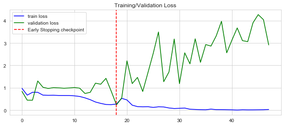

```python
#input_dim, hidden_dim, output_dim, num_layers
pack=True
model = BasicLSTM(768, 50, 10, 2, drop_prob=0.1, bidirectional=True, printing=False, pack=pack)

n_epochs = 200
lr=0.01
earlyStopping= {
    'patience': 30,
    'min_delta': 1e-5,
    'break': True
}
checkpoints={
    'filename': 'best_lstm.pt'
}


criterion = nn.CrossEntropyLoss()
optimizer = torch.optim.Adam(model.parameters(), lr=lr)

train_losses, val_losses, earlyStoppingEpoch= train_model(model, n_epochs, lr, criterion, optimizer, checkpoints=checkpoints, earlyStopping=earlyStopping, pack=pack)


print_loss_curve(train_losses,val_losses,earlyStoppingEpoch)
```

#### As you will see, the LSTM didn't perfom well enough in comparison with the rest classifiers. The 2 main reasons are:

The small size of the train set

The naive representation of the documents. As I already mentioned, I appended the word embeddings of all the words after preprocessing.

#### Load the best LSTM model

```python
pack=True
lr=0.01

model = BasicLSTM(768, 50, 10, 2, drop_prob=0.1, bidirectional=True, printing=False, pack=pack)
optimizer = torch.optim.Adam(model.parameters(), lr=lr)

checkpoint = torch.load(pickles_path+'best_lstm.pt')
model.load_state_dict(checkpoint['model_state_dict'])
optimizer.load_state_dict(checkpoint['optimizer_state_dict'])
epoch = checkpoint['epoch']
train_loss = checkpoint['train_loss']
val_loss= checkpoint['val_los']

print('this is the best model\n')

model.eval()
```

```
this is the best model
```

```
BasicLSTM(
  (lstm): LSTM(768, 100, num_layers=2, batch_first=True, dropout=0.1, bidirectional=True)
  (dropout): Dropout(p=0.1, inplace=False)
  (fc1): Linear(in_features=200, out_features=64, bias=True)
  (fc2): Linear(in_features=64, out_features=10, bias=True)
)
```

```python
loaders= [train_loader_p, validation_loader_p, test_loader_p]
loadersNames= ['train set', 'validation set', 'test set']

for i,loader in enumerate(loaders):
    outputs, true_labels= [], []
    for inputs, lengths, labels in loader:
        output = model(inputs, lengths)
        outputs.append(np.argmax(output.detach().numpy(),axis=1))
        true_labels.append(labels.detach().numpy())

    outputs= [x for out in outputs for x in out] #restore the strange pytorch represantation
    true_labels= [x for lab in true_labels for x in lab]
    total= len(true_labels)
    TP= sum( np.equal(outputs, true_labels) )
    print('Accuracy {:0.2f}% [{}]'.format(TP*100/total, loadersNames[i]))
```

```
Accuracy 65.67% [train set]
Accuracy 87.00% [validation set]
Accuracy 60.61% [test set]
```

LSTM optimization  
92.0 - 65.67 = 26.33% avoidable bias -> Solution: Train longer, Choose Better Optimization Algoithm, Hyperparameters Search  
87.00 - 65.67 = 21.33% variance -> Solution: Regulatization/Dropout/Data Augmentation, Bigger Training Set, Hyperparameters Search

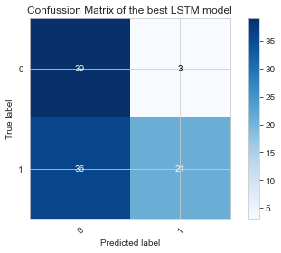

```python
fig, ax = plt.subplots()
plot_confusion_matrix(true_labels, outputs, fig, ax, allClasses=np.arange(2), title='Confussion Matrix of the best LSTM model');
```